[figure not shown]

# Inference Procedures

### {Using R for Inference Procedures}

- [1] Paired t-test
- [2] Single Sample Tests for Proportions
- [3] Two Sample Test for Proportions
- [4] Test for the equality of variances for two samples
- [5] Shapiro-Wilk Test for Normality
- [6] Graphical procedures for assessing normality

#### {p-values using R}

- In every inference procedure performed using R, a p-value is presented to the screen for the user to interpret.
- If the p-value is larger than a specified threshold $alpha/k$ then the appropriate conclusion is a failure to reject the null hypothesis.
- Conversely, if the p-value is less than threshold, the appropriate conclusion is to reject the null hypothesis.
- In this module, we will use a significance level$alpha=0.05$ and almost always the procedures will be two tailed ($k=2$). Therefore the threshold $alpha/k$ will be $0.025$.

### {Using Confidence Limits}

- Alternatively, we can use the confidence interval to make a decision on whether or not we should reject or fail to reject the null hypothesis.
- If the null value is within the range of the confidence limits, we fail to reject the null hypothesis.
- If the null value is outside the range of the confidence limits, we reject the null hypothesis.
- Occasionally a conclusion based on this approach may differ from a conclusion based on the p-value. In such a case, remark upon this discrepancy.

### {The paired t-test }

- Previously we have seen the paired t-test. It is used to determine whether or not there is a significant difference between paired measurements. Equivalently whether or not the case-wise differences are zero.
- The mean and standard deviation of the case-wise differences are used to determine the test statistic.
- Under the null hypothesis, the expected value of the case-wise differences is zero (i.e $H_0 : mu_d = 0$).
  $$TS = frac{bar{d} - mu_d}{frac{s_d}{sqrt{n}}}$$
- The calculation is dependent on the case-wise differences
- Here the case-wise differences between paired measurements (e.g. `before" and`after“)
- The test statistic can be computed using the following R code, where texttt{CWdiff} is the case-wise differences. * The mean, standard deviation and sample size are presented in the next slide.

`> CWdiff = Before - After > mean(CWdiff) [1] 8.214286 > sd(CWdiff) [1] 7.904999 > length(CWdiff) [1] 14`

Implementing the paired t-test using R. `> t.test(Before,After,paired=TRUE)`

```
    Paired t-test
```

data: Before and After t = 3.8881, df = 13, p-value = 0.001868 alternative hypothesis: true difference in means is not 0 95 percent confidence interval: 3.650075 12.778496 sample estimates: mean of the differences 8.214286

- The p-value ($0.001868$) is less than the threshold is less than the threshold $0.0250$
- We reject the null hypothesis (mean of case-wise differences being zero, i.e. expect no difference between `before" and`after“)
- We conclude that there is a difference between `before' and`after’.
- That is to say, we can expected a difference between two paired measurements.
- We consider the confidence interval. We are $95%$ confident that the expected value of the case-wise difference is at least 3.65.
- Here the null value (i.e. 0) is not within the range of the confidence limits.
- Therefore we reject the null hypothesis.

`> t.test(Before,After,paired=TRUE) … … 95 percent confidence interval: 3.650075 12.778496 …`

### {Single Sample Proportion Test (a)}

- In this procedure, we determine whether or not we are are justified in assuming that the population proportion takes a certain value.
- For example, suppose we believed that the population proportion of students with iphones or androids was $80%$.
- We would write the null and alternative accordingly. [H_0 : pi = 80% ][H_1 : pi neq 80% ]
- The appropriate R command is texttt{prop.test(x,n,p)}
- $x$ is the number of successes, $n$ is the sample size and $p$ is the population proportion assumed under the null hypothesis.
- Suppose we survey 65 students, with 50 replying that they had an iphone or android.

`> prop.test(50,65,0.80)`

```
    1-sample proportions test
```

data: 50 out of 65, null probability 0.8 X-squared = 0.2163, df = 1, p-value = 0.6418 alternative hypothesis: true p is not equal to 0.8 95 percent confidence interval: 0.6452269 0.8610191 sample estimates: p 0.7692308

- The p-value is above the threshold. Therefore we fail to reject the null hypothesis that the population proportion ($pi$) is $80%$.
- The observed proportion is a very straightforward calculation:

[ hat{p} = frac{50}{65} = 0.76923= 76.92%] * Nonetheless, you would be required to show how it was calculated.

#### Test of Equality for Two Sample Proportions

The null hypothesis is that two populations have the same proportions for a particular characteristic. [H_0 : pi_1 = pi_2 ][H_1 : pi_1 neq pi_2 ]

- The command is texttt{prop.test(c(x1,x2),c(n1,n2))}
- $x1$ and $x2$ are the number of successes from both samples.
- $n2$ and $n2$ are the sample sizes for both groups.
- The difference in population proportions assumed under the null hypothesis is zero.
- (It is possible to specify a different null value, but we will not consider this in this module.)
- Consider a study where the proportion of Irish students who owned mobile devices, such as iphones and androids was compared to the corresponding proportion of French student.
- As before, $65$ Irish students were interviewed, with $50$ replying that they owned mobile devices.
- $90$ french students were interview, with 60 responding that they owned mobile devices.
- The test of equality of proportions is implemented on the next slide.

Based on the p-value, we fail to reject the null hypothesis. There is not enough evidence to assume a difference in proportions. Also the expected difference assumed under the null hypothesis, i.e. 0, is contained in the confidence interval. `> prop.test(c(50,60),c(65,90))`

```
    2-sample test for equality of proportions
```

data: c(50, 60) out of c(65, 90) X-squared = 1.4613, df = 1, p-value = 0.2267 alternative hypothesis: two.sided 95 percent confidence interval: -0.05202058 0.25714878 sample estimates: prop 1 prop 2 0.7692308 0.6666667

- You would be required to compute the differences in observed proportions.
- Additionally you will given the R code for one sample procedures. This may or may not be relevant for answering the question.

```
> prop.test(60,90,0.80)
...
...
X-squared = 9.184, df = 1, p-value = 0.002441
alternative hypothesis: true p is not equal to 0.8
95 percent confidence interval:
 0.5585219 0.7604058
sample estimates:
        p
0.6666667
```

### Shapiro-Wilk Test

- We will often be required to determine whether or not a data set is normally distributed.
- Again, this assumption underpins many statistical models.
- The null hypothesis is that the data set is normally distributed.
- The alternative hypothesis is that the data set is not normally distributed.
- One procedure for testing these hypotheses is the Shapiro-Wilk test, implemented in R using the command texttt{shapiro.test()}.
- (Remark: You will not be required to compute the test statistic for this test.)

```
> shapiro.test(x)

        Shapiro-Wilk normality test

data:  x
W = 0.9474, p-value = 0.6378

> shapiro.test(y)

        Shapiro-Wilk normality test

data:  y
W = 0.9347, p-value = 0.5273
```

### {Graphical Procedures for assessing Normality}

# Customizing Startup

### Customizing Startup

You can customize the R environment through a site initialization file or a directory initialization file. R will always source the Rprofile.site file first. On Windows, the file is in the `C:\\Program Files\\R\\R-n.n.n\\etc` directory. You can also place a .Rprofile file in any directory that you are going to run R from or in the user home directory.

At startup, R will source the Rprofile.site file. It will then look for a .Rprofile file to source in the current working directory. If it doesn’t find it, it will look for one in the user’s home directory. There are two special functions you can place in these files. .First( ) will be run at the start of the R session and .Last( ) will be run at the end of the session.

```
# Sample Rprofile.site file

# Things you might want to change
 # options(papersize="a4")
# options(editor="notepad")
# options(pager="internal")

 # R interactive prompt
# options(prompt="> ")
 # options(continue="+ ")

# to prefer Compiled HTML
help options(chmhelp=TRUE)
# to prefer HTML help
# options(htmlhelp=TRUE)

# General options
options(tab.width = 2)
options(width = 130)
 options(graphics.record=TRUE)

.First <- function(){
  library(Hmisc)
  library(R2HTML)
  cat("\nWelcome at", date(), "\n")
}

 .Last <- function(){
 cat("\nGoodbye at ", date(), "\n")
 }
```

# Plots

### Plots

This section is an introduction for producing simple graphs with the R Programming Language.

#### Histograms

[output not shown]

``R} automatically chooses the number and width of the bars. We can change this by specifying the location of the break points.

[output not shown]

Boxplots can be used to identify outliers.

By default, the `boxplot()` command sets the orientation as vertical. By adding the argument ``horizontal=TRUE}, the orientation can be changed to horizontal.

```
boxplot(mtcars$mpg, horizontal=TRUE, xlab="Miles Per Gallon",
main="Boxplot of MPG")
```

# R Environment

### Time and Date functions

The commands `Sys.time()` and `Sys.Date()` returns the system’s idea of the current date with and without time. We can perform some simple algebraic calculations to compute time differences (i.e. to find out how long some code took to compile.)

```
> X1=Sys.time()
> #Wait a few seconds
>
> X2=Sys.time()
> X2-X1
Time difference of 8.439614 secs
>
> Sys.Date()
[1] "2012-09-01"
```

### Built-In Data Sets

Several data sets , intended as learning tools, are automatically installed when R is installed. Many more are installed within packages to complement learning to use those packages. One of these is the famous Iris data set, which is used in many data mining exercises. * iris * mtcars * Nile To see what data sets are available, simply type data(). To load a data set, simply type in the name of the data set. Some data sets are very large. To just see the first few (or last) rows, we use the head() function or alternatively the tail() function. The default number of rows of these commands is 6. Other numbers can be specified.

```
> head(iris)
Sepal.Length Sepal.Width Petal.Length Petal.Width Species
1 5.1 3.5 1.4 0.2 setosa
2 4.9 3.0 1.4 0.2 setosa
3 4.7 3.2 1.3 0.2 setosa
4 4.6 3.1 1.5 0.2 setosa
5 5.0 3.6 1.4 0.2 setosa
6 5.4 3.9 1.7 0.4 setosa
>
> tail(iris,4)
Sepal.Length Sepal.Width Petal.Length Petal.Width Species
147 6.3 2.5 5.0 1.9 virginica
148 6.5 3.0 5.2 2.0 virginica
149 6.2 3.4 5.4 2.3 virginica
150 5.9 3.0 5.1 1.8 virginic
```

In many situations, it is useful to call a particular data set using the attach() command. This will save having to specify the data sets over repeated operations. The file can then be detached using the detach() command.

### The `summary()` command

The R command summary() is a generic function used to produce result “summaries” of the results of various objects, from simple vectors to the output of complex model fitting functions. The function invokes particular methods which depend on the class of the first argument.

```
> summary(Nile)
Min. 1st Qu. Median Mean 3rd Qu. Max.
456.0 798.5 893.5 919.4 1032.0 1370.0
>
> summary(Indometh)
Subject time conc
1:11 Min. :0.250 Min. :0.0500
4:11 1st Qu.:0.750 1st Qu.:0.1100
2:11 Median :2.000 Median :0.3400
5:11 Mean :2.886 Mean :0.5918
6:11 3rd Qu.:5.000 3rd Qu.:0.8325
3:11 Max. :8.000 Max. :2.7200
```

### Working directories

```
> getwd()
[1] "C:/Users/Kevin"
>
> setwd("C:/Users/Kevin/Documents")
>
> getwd()
[1] "C:/Users/Kevin/Documents"
```

### Coming Unstuck

If you are having trouble with a piece of code that is currently compiling , all you have to do is press ESC, just like many other computing environments.

### Quitting the environment

# Data Objects

### Objects

- Vectors
- Lists
- Dataframes
- Matrices

The simple objects we have created previously are simply single element vectors.

# Downloading and Installing R

R can be started in the usual way by double-clicking on the R icon on the desktop.

#### Working Directory

R works best if you have a dedicated folder for each separate project - called the working directory. Create the directory/folder that will be used as the working folder, e.g. create a folder on your desktop titled Your_name by right-clicking, then clicking New > Folder. Right-click on an existing R icon and click Copy. In the working folder, right-click and click Paste. The R icon will appear in the folder.

#### Introduction to R

R is an open source implementation of the S-Plus language. It is freely available and is licensed under the GPL. The language simplifies many statistical computations and can be a powerful tool. R is typically used by statisticians as a tool for direct data analysis.

R software and packages can be downloaded from Comprehensive R Archive Network (CRAN; http: //cran.r-project.org).

R is under very active development and is constantly gaining “market shares” in many fields related to statistics, such as finance, data mining, genomics and pharmaceuticals.

#### Downloading and Installing R

Click on Windows > base > R-version-win32.exe > Run and follow the instructions to install the programme.

# Base Graphics

### Enhancing your scatter plots

### Adding lines

Previously we have used scatter plots to plot bivariate data. They were constructed using the `plot()` command. Recall that we can use the arguments `xlim` and `ylim` to control the vertical and horizontal range of the plots, by specifying a two element vector (min and max) for each.

The line types are follows

- `lty =1` Normal full line (default)
- `lty =2` Dashed line
- `lty =3` Dotted line
- `lty =4` Dash-dot line

### Changing your plot character

To change the plot character (the symbol for each covariate, we supply an additional argument to the plot() function. This argument is formulated as pch=n where n is some number. Additionally we change the colour of the characters, by specifying a colour in the col argument. Recall that we can add new variates to an existing scatterplot using the points() function. Remember to set the vertical and horizontal limits accordingly.

### Adding the regression model line

The `abline()` function can be used to add a regression model line by supplying as an argument the `coef()` values for intercept and slope estimates .These estimates can be inputted directly by using both functions in conjunction.

### Adding a title

We can also add text to each margin, using the `mtext()` command.  
We simply require the number of the side. (1 = bottom, 2=left,3=top,4=right). We can change the colour using the col argument.

[output not shown]

### Combining plots It is possible to combine two plots. We used the graphical parameters command `par()` to create an array. Often we just require two plots side by side or above and below. We simply specify the numbers of rows and columns of this array using the `mfrow` argument, passed as a vector.

### Plot of single vectors

If only one vector is specified i.e. `plot(x)`, the plot created will simply be a scatter-plot of the values of x against their indices.

$plot(x)$ Suppose we wish to examine a trend that these points represent. We can connect each covariate using a line.

$plot(x, type = "l")$ If we wish to have both lines and points, we would input the following code. This is quite useful if we wish to see how a trend develops over time. $plot(x, type = "b")$

# Boxplots

### Boxplots

Boxplots can be used to identify outliers.

By default, the `boxplot()` command sets the orientation as vertical.

By adding the argument `horizontal=TRUE`, the orientation can be changed to horizontal.

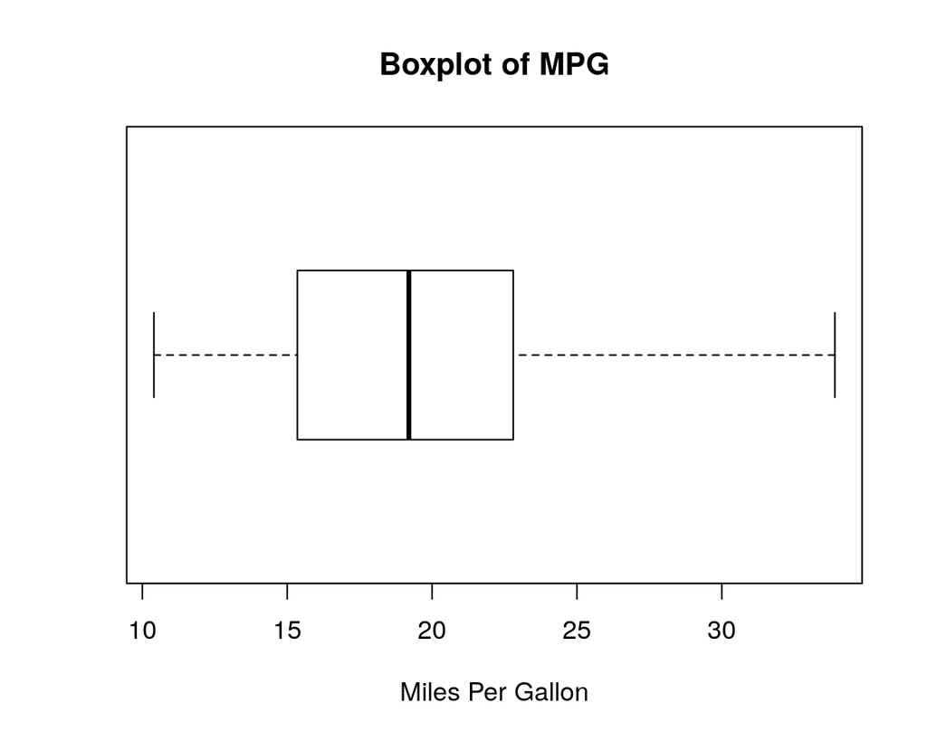

```r
boxplot(mtcars$mpg, horizontal=TRUE, xlab="Miles Per Gallon",
main="Boxplot of MPG")
```

# Descriptive and Quantile Statistics

### Statistics

Some simple ones to start with

mean() range() min() max() median() IQR() fivenum()

Measures of Dispersion range variance covariance standard deviation

sum